# Assignment 1 Garzaniti Sports Analytics

Josh Garzaniti

2024-10-30

##Libraries

```r
library(ggplot2)
library(ggdark)
library(tidyr)
library(ggnewscale)
library(ggrepel)
library(Gini)
library(dplyr)
library(mice)
```

##Loading in data

##Summary of the Data

```r
summary(PGA)
```

```
##  Player.Name            Rounds       Fairway.Percentage      Year
##  Length:2312        Min.   : 45.00   Min.   :43.02      Min.   :2010
##  Class :character   1st Qu.: 69.00   1st Qu.:57.94      1st Qu.:2012
##  Mode  :character   Median : 79.50   Median :61.43      Median :2014
##                     Mean   : 78.71   Mean   :61.44      Mean   :2014
##                     3rd Qu.: 89.00   3rd Qu.:64.91      3rd Qu.:2016
##                     Max.   :120.00   Max.   :76.88      Max.   :2018
##                     NA's   :634      NA's   :634
##   Avg.Distance        gir        Average.Putts   Average.Scrambling
##  Min.   :266.4   Min.   :53.54   Min.   :27.51   Min.   :44.01
##  1st Qu.:284.9   1st Qu.:63.83   1st Qu.:28.81   1st Qu.:55.90
##  Median :290.6   Median :65.79   Median :29.14   Median :58.27
##  Mean   :290.8   Mean   :65.66   Mean   :29.16   Mean   :58.12
##  3rd Qu.:296.4   3rd Qu.:67.58   3rd Qu.:29.52   3rd Qu.:60.42
##  Max.   :319.7   Max.   :73.52   Max.   :31.00   Max.   :69.33
##  NA's   :634     NA's   :634     NA's   :634     NA's   :634
##  Average.Score      Points               Wins           Top.10
##  Min.   :68.70   Length:2312        Min.   :1.000   Min.   : 1.000
##  1st Qu.:70.49   Class :character   1st Qu.:1.000   1st Qu.: 1.000
##  Median :70.90   Mode  :character   Median :1.000   Median : 2.000
##  Mean   :70.92                      Mean   :1.218   Mean   : 2.782
##  3rd Qu.:71.34                      3rd Qu.:1.000   3rd Qu.: 4.000
##  Max.   :74.40                      Max.   :5.000   Max.   :14.000
##  NA's   :634                        NA's   :2019    NA's   :854
##  Average.SG.Putts  Average.SG.Total      SG.OTT            SG.APR
##  Min.   :-1.4750   Min.   :-3.2090   Min.   :-1.7170   Min.   :-1.6800
##  1st Qu.:-0.1870   1st Qu.:-0.2547   1st Qu.:-0.1902   1st Qu.:-0.1808
##  Median : 0.0400   Median : 0.1470   Median : 0.0560   Median : 0.0810
##  Mean   : 0.0256   Mean   : 0.1481   Mean   : 0.0378   Mean   : 0.0650
##  3rd Qu.: 0.2570   3rd Qu.: 0.5685   3rd Qu.: 0.2915   3rd Qu.: 0.3145
##  Max.   : 1.1300   Max.   : 2.4060   Max.   : 1.4850   Max.   : 1.5330
##  NA's   :634       NA's   :634       NA's   :634       NA's   :634
##      SG.ARG          Money
##  Min.   :-0.930   Length:2312
##  1st Qu.:-0.123   Class :character
##  Median : 0.022   Mode  :character
##  Mean   : 0.020
##  3rd Qu.: 0.175
##  Max.   : 0.660
##  NA's   :634
```

```r
head(PGA)
```

```
##      Player.Name Rounds Fairway.Percentage Year Avg.Distance   gir
## 1 Henrik Stenson     60              75.19 2018        291.5 73.51
## 2    Ryan Armour    109              73.58 2018        283.5 68.22
## 3    Chez Reavie     93              72.24 2018        286.5 68.67
## 4     Ryan Moore     78              71.94 2018        289.2 68.80
## 5   Brian Stuard    103              71.44 2018        278.9 67.12
## 6      Brian Gay    103              71.37 2018        282.9 64.52
##   Average.Putts Average.Scrambling Average.Score Points Wins Top.10
## 1         29.93              60.67        69.617    868   NA      5
## 2         29.31              60.13        70.758  1,006    1      3
## 3         29.12              62.27        70.432  1,020   NA      3
## 4         29.17              64.16        70.015    795   NA      5
## 5         29.11              59.23        71.038    421   NA      3
## 6         28.25              63.26        70.280    880   NA      6
##   Average.SG.Putts Average.SG.Total SG.OTT SG.APR SG.ARG      Money
## 1           -0.207            1.153  0.427  0.960 -0.027 $2,680,487
## 2           -0.058            0.337 -0.012  0.213  0.194 $2,485,203
## 3            0.192            0.674  0.183  0.437 -0.137 $2,700,018
## 4           -0.271            0.941  0.406  0.532  0.273 $1,986,608
## 5            0.164            0.062 -0.227  0.099  0.026 $1,089,763
## 6            0.442            0.565 -0.166  0.036  0.253 $2,152,501
```

```r
colSums(is.na(PGA))
```

```
##        Player.Name             Rounds Fairway.Percentage               Year
##                  0                634                634                  0
##       Avg.Distance                gir      Average.Putts Average.Scrambling
##                634                634                634                634
##      Average.Score             Points               Wins             Top.10
##                634                  0               2019                854
##   Average.SG.Putts   Average.SG.Total             SG.OTT             SG.APR
##                634                634                634                634
##             SG.ARG              Money
##                634                  0
```

##Impute NA’s

```r
PGA = PGA%>%
  mutate(across(c(Wins, Top.10), ~ replace_na(.x, 0)))

imputed_PGA = mice(PGA, m = 1, maxit = 50, method = 'pmm', seed = 719)
PGA_imputed = complete(imputed_PGA)

PGA_clean = PGA_imputed %>%
  mutate(across(everything(), ~ ifelse(is.na(.x), 0, .x)))

colSums(is.na(PGA_clean))
```

```
##        Player.Name             Rounds Fairway.Percentage               Year
##                  0                  0                  0                  0
##       Avg.Distance                gir      Average.Putts Average.Scrambling
##                  0                  0                  0                  0
##      Average.Score             Points               Wins             Top.10
##                  0                  0                  0                  0
##   Average.SG.Putts   Average.SG.Total             SG.OTT             SG.APR
##                  0                  0                  0                  0
##             SG.ARG              Money
##                  0                  0
```

Just Used Mice here to clean up some of the NA’s across the board for the PGA dat(mostly stroke gained variables).

## Initial Visualizations

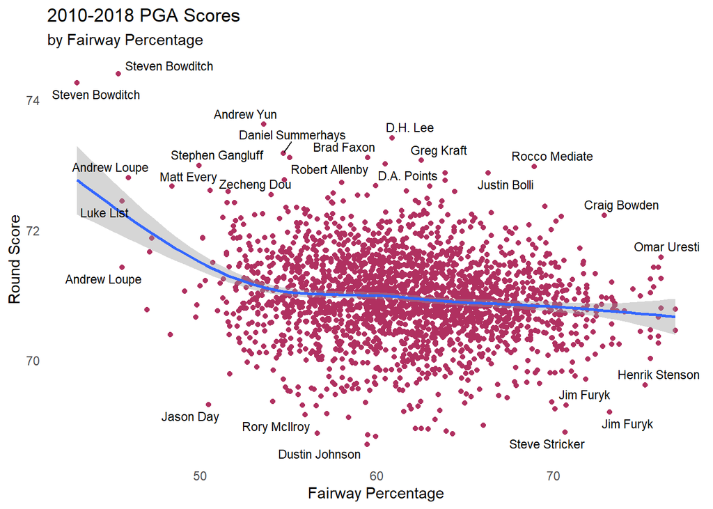

```r
Fairway_score = ggplot(data = PGA_clean, aes(x = Fairway.Percentage, y = Average.Score))+
  geom_point(color = "maroon")+
  theme_minimal()+
  ggtitle(label = "2010-2018 PGA Scores", subtitle = "by Fairway Percentage")+
  labs(x = "Fairway Percentage", y = "Round Score", color = "Player")+
  geom_smooth()+
  geom_text_repel(aes(label = Player.Name),
                  size = 3, color = "black")+
  theme(panel.grid.major = element_blank(),
        panel.grid.minor = element_blank())

Fairway_score
```

This is a basic scatter plot displaying what players on the tour have shot in terms of their overall average round score by how often they find the fairway on their tee shots. As you can imagine, those who are finding the fairway more often(really above 50%), tend to shoot par(implied 72) or better each round. There is some variance in scores suggesting that anything within the 55-70%+ range is beneficial, but not exponentially increasing the odds of scoring lower rounds. ## Putts vs Score Visualization

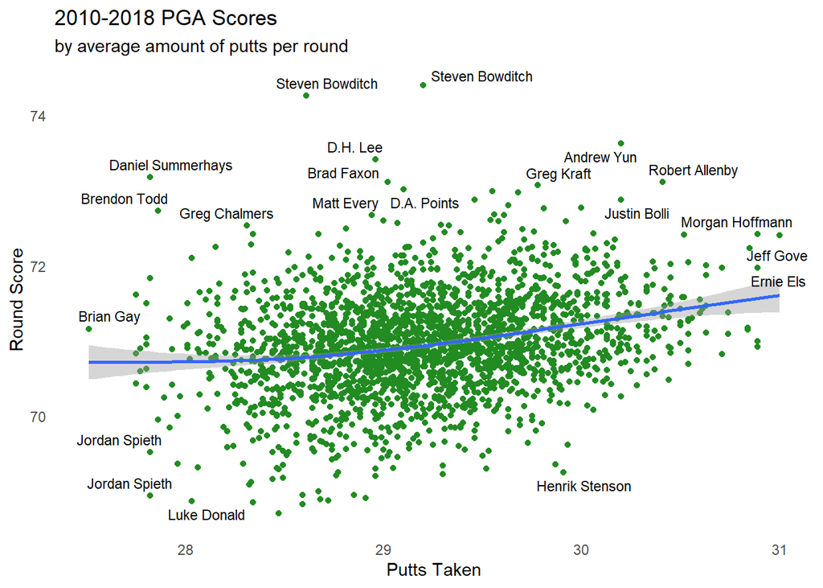

```r
Putts_score = ggplot(data = PGA_clean, mapping = aes(x = Average.Putts, y = Average.Score))+ geom_point(color = "forestgreen")+
  theme_minimal()+
  ggtitle(label = "2010-2018 PGA Scores", subtitle = "by average amount of putts per round")+
  labs(x = "Putts Taken", y = "Round Score", color = "Player")+
  geom_smooth()+
  geom_text_repel(aes(label = Player.Name),
                  size = 3, color = "black")+
  theme(panel.grid.major = element_blank(),
        panel.grid.minor = element_blank())

Putts_score
```

Another scatter plot, this time displaying the round score of PGA players by the average amount of putts they make in a given round. Interesting to note that between 2010 and 2018, short game specialists like Spieth were averaging less than 28 putts per round(When it’s often considered average to 2-putt a hole, which leads to 36 regulation putt attempts). But also a very straightforward graphic. As your putting attempts increase, you’re often lagging behind in the short game or having to make up strokes for poor play elsewhere, which lead to higher scores. ##Greens in Regulation

```r
max(PGA_clean$Top.10)
```

```
## [1] 14
```

```r
is.na(PGA$Top.10)
```

[output not shown]

[output cut: 178 more lines]

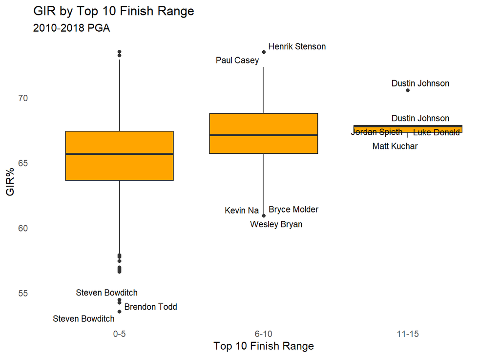

```r
PGA_clean%>%
  mutate(Top10_bins = cut(Top.10, breaks = c(0, 5, 10, 15),
                          labels = c("0-5", "6-10", "11-15"),
                          right = FALSE))%>%
  ggplot(aes(x = Top10_bins, y = gir)) +
  geom_boxplot(fill = "orange") +
  theme_minimal() +
  ggtitle("GIR by Top 10 Finish Range", subtitle = "2010-2018 PGA") +
  labs(x = "Top 10 Finish Range", y = "GIR%")+
  geom_text_repel(aes(label = Player.Name),
                  size = 3, color = "black")+
  theme(panel.grid.major = element_blank(),
        panel.grid.minor = element_blank())
```

I created 3 main “top 10 tour finish bins” to have this bar chart display and then fitted them by the Greens in Regulation percentage or GIR for each tour player. What GIR tracks is how often a player is making it onto the green with at least 2 putts lefts for par. So for a par 3, it’s when they make it on the green with their drive, for par 4’s when they’re on in 2 shots, and par 5’s… 3 shots. It’s the equivalent of “baseball players being on/ahead of the count for batting, or a nfl football team being ahead or on pace with the chains while they’re on offense”. There are some outliers in the data, but there is also a positive trend of binned players who have a better GIR%, also having more top 10 finishes. Consistency. Is. Key. ##Scrambling Analysis

```r
max(PGA_clean$Average.Scrambling)
```

```
## [1] 69.33
```

```r
min(PGA_clean$Average.Scrambling)
```

```
## [1] 44.01
```

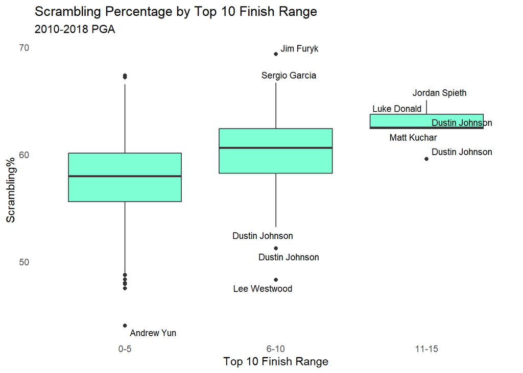

```r
PGA_clean%>%
  mutate(Top10_bins = cut(Top.10, breaks = c(0, 5, 10, 15),
                          labels = c("0-5", "6-10", "11-15"),
                          right = FALSE))%>%
  ggplot(aes(x = Top10_bins, y = Average.Scrambling)) +
  geom_boxplot(fill = "aquamarine") +
  theme_minimal() +
  ggtitle("Scrambling Percentage by Top 10 Finish Range", subtitle = "2010-2018 PGA") +
  labs(x = "Top 10 Finish Range", y = "Scrambling%")+
  geom_text_repel(aes(label = Player.Name),
                  size = 3, color = "black")+
  theme(panel.grid.major = element_blank(),
        panel.grid.minor = element_blank())
```

Here is another top 10 binned graphic which displays the three main finish player categories by scrambling percentage. Think of scrambling percentage as how often a golfer makes par or better when they miss the GIR. e.g. a golfer hits their par 3 drive and it lands in the rough away from the green but then chips in for birdie or completes a successful “up and down”. It’s the equivalent to being behind the sticks in football on offense, but still finding a way to convert on 3rd down/ 4th down even when early down success percentage is below average standards. Once again we’re seeing players like Spieth and Dustin Johnson excel in terms of top 10 placements because of their adaptability when it comes to making up shots around the green. ##Shots Gained Analysis

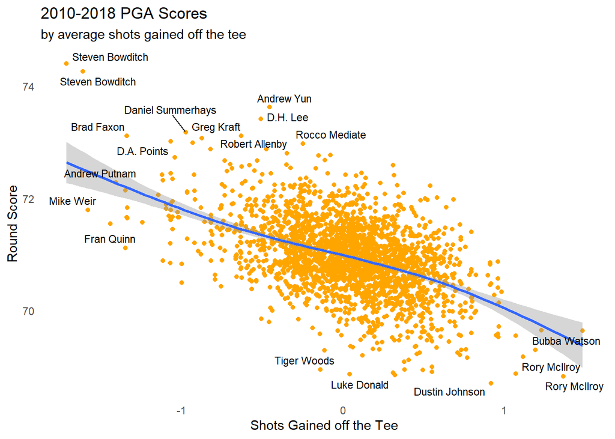

```r
TeeSG_score = ggplot(data = PGA_clean, mapping = aes(x = SG.OTT, y = Average.Score))+ geom_point(color = "orange")+
  theme_minimal()+
  ggtitle(label = "2010-2018 PGA Scores", subtitle = "by average shots gained off the tee")+
  labs(x = "Shots Gained off the Tee", y = "Round Score", color = "Player")+
  geom_smooth()+
  geom_text_repel(aes(label = Player.Name),
                  size = 3, color = "black")+
  theme(panel.grid.major = element_blank(),
        panel.grid.minor = element_blank())

TeeSG_score
```

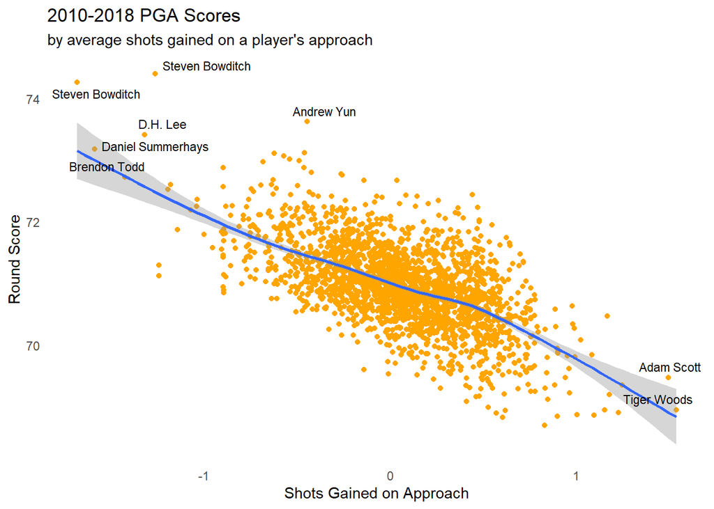

```r
ApproachSG_score = ggplot(data = PGA_clean, mapping = aes(x = SG.APR, y = Average.Score))+ geom_point(color = "orange")+
  theme_minimal()+
  ggtitle(label = "2010-2018 PGA Scores", subtitle = "by average shots gained on a player's approach")+
  labs(x = "Shots Gained on Approach", y = "Round Score", color = "Player")+
  geom_smooth()+
  geom_text_repel(aes(label = Player.Name),
                  size = 3, color = "black")+
  theme(panel.grid.major = element_blank(),
        panel.grid.minor = element_blank())

ApproachSG_score
```

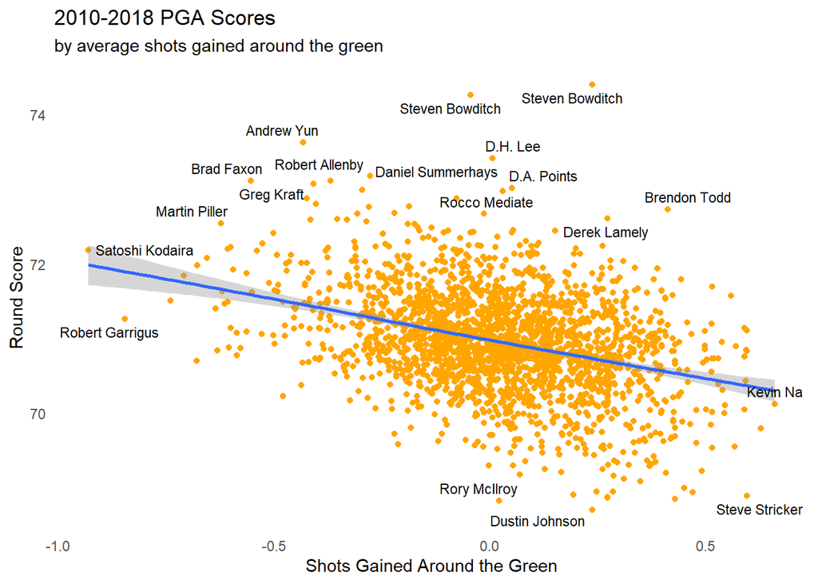

```r
AroundGreen_score = ggplot(data = PGA_clean, mapping = aes(x = SG.ARG, y = Average.Score))+ geom_point(color = "orange")+
  theme_minimal()+
  ggtitle(label = "2010-2018 PGA Scores", subtitle = "by average shots gained around the green")+
  labs(x = "Shots Gained Around the Green", y = "Round Score", color = "Player")+
  geom_smooth()+
  geom_text_repel(aes(label = Player.Name),
                  size = 3, color = "black")+
  theme(panel.grid.major = element_blank(),
        panel.grid.minor = element_blank())

AroundGreen_score
```

I’m still cleaning up a bit). The end goal is either using more advanced modeling and visualizations to break down PGA tour player analysis on these different shot levels or cater it to a unique golf course I.e Augusta National where the tournament takes place in the same location each year and then data analysis can be performed using these Shots Gained metrics to predict tournament performance. That data I would probably pull from getting a subscription using https://datagolf.com/historical-tournament-stats?event_id=14&year=2024.